# Uniform Inference Near the Boundary

## Introduction

Consider a parametric model parameterized by \(\theta\).

A confidence region has *asymptotically correct coverage probability (uniformly) on compact sets* if for every compact \(\mathbb{A} \subset \Theta\),

\[ \lim_{n \rightarrow \infty} \sup_{\theta \in \mathbb{A}} \left| P_{\theta}(\theta \in C_n(\alpha)) - (1-\alpha) \right| = 0 \]

The above holds if and only if for every sequence \((\theta_n)\) convergent in \(\Theta\),

\[ \lim_{n \rightarrow \infty} \left| P_{\theta_n}(\theta_n \in C_n(\alpha)) - (1-\alpha) \right| = 0 \]

## Introduction

Let \(\theta = (\psi, \lambda)\), \(\psi\) is parameter of interest, \(\lambda\) nuisance.

Similarly, for a confidence region for \(\psi\), we have that

\[ \lim_{n \rightarrow \infty} \sup_{\theta \in \mathbb{A}} \left| P_{\theta}(\psi \in C_n(\alpha)) - (1-\alpha) \right| = 0 \]

iff for every sequence \((\theta_n) = (\psi_n, \lambda_n)\) convergent in \(\Theta\),

\[ \lim_{n \rightarrow \infty} \left| P_{\theta_n}(\psi_n \in C_n(\alpha)) - (1-\alpha) \right| = 0 \]

## Introduction

- We will construct confidence intervals by inverting a test, with test statistic \(T_n(\psi)\)
- Deriving a uniformly asymptotically valid confidence interval requires knowing the distributional limit of \(T_n(\psi_n)\) under a sequence of parameter values \((\theta_n)\).
- This distribution often depends on both the limit \(\theta_0\) of the sequence, and the rate of convergence of the sequence.
- This dependence prohibits us from constructing confidence intervals in some situations, but not in others. We can also work around it by conditioning on sufficient statistics.

## Example: James Stein

- The following example shows the proposed method in a situation with an exactly quadratic likelihood (normal mean).

**Definition**: An estimator sequence \(T_n\) is called *regular* at \(\theta\) for estimating a parameter \(g(\theta)\) if, for every \(h\),

\[ \sqrt{n} \left( T_n - g \left(\theta + \frac{h}{\sqrt{n}} \right) \right) \overset{\theta+h/\sqrt{n}}\leadsto L_{\theta} \]

where the probability measure \(L_{\theta}\) is arbitrary, but the same for every \(h\).

- A common problem is to search for the best estimator among regular estimators, excluding shrinkage estimators like the Stein shrinkage estimator.

## Example: James Stein

Let \(X_1, \cdots, X_n \sim N_k(\theta, I_k)\), \(k \geq 3\). Consider the following estimator of \(\theta\):

\[ \delta(\bar{X}_n) = \bar{X}_n - (k-2) \frac{\bar{X}_n}{n ||\bar{X}_n||^2} \]

Suppose \((\theta_n)\) is a convergent sequence in \(\mathbb{R}^k\) such that \(\theta_n \rightarrow \theta_0\). Define

\[ \begin{aligned} T_n(\theta_n) &= \sqrt{n}(\delta(\bar{X}_n) - \theta_n) \\ &= \sqrt{n} \bar{X}_n - (k-2) \frac{\bar{X}_n}{\sqrt{n}||\bar{X}_n||^2} - \sqrt{n} \theta_n \end{aligned} \]

## Example: James Stein

\[ T_n(\theta_n) = \sqrt{n} \bar{X}_n - (k-2) \frac{\bar{X}_n}{\sqrt{n}||\bar{X}_n||^2} - \sqrt{n} \theta_n \]

where under \(\theta = \theta_n\),

\[ \sqrt{n} \bar{X}_n \overset{\theta_n}\sim N(\sqrt{n}\theta_n, nI_k) \]

so

\[ T_n(\theta_n) \overset{\theta_n}\sim Z - (k-2) \frac{X^*_n}{||X^*_n||^2} \]

\(Z \sim N(0, I_k)\) and \(X_n^* \sim N(\sqrt{n}\theta_n, I_k)\).

## Example: James Stein

\[ T_n(\theta_n) \overset{\theta_n}\sim Z - (k-2) \frac{X^*_n}{||X^*_n||^2} \]

\(Z \sim N(0,I_k)\) and \(X_n^* \sim N(\sqrt{n}\theta_n, I_k)\).

- If \(\theta_n \rightarrow \theta_0 \neq 0\), then at least one element of \(\sqrt{n}\theta_n\) diverges, the second term converges in probability to \(0\), \(T_n(\theta_n) \overset{\theta_n}\leadsto N(0, I_k)\).
  - In particular, considering sequences of the form \(\theta_n = \theta_0 + h/\sqrt{n}\), this shows that the estimator is regular at \(\theta \neq 0\).
- If \(\theta_n \rightarrow 0\) but at a rate slow enough such that at least one element \(\sqrt{n}\theta_n\) diverges, \(T_n(\theta_n) \overset{\theta_n}\leadsto N(0, I_k)\).

## Example: James Stein

\[ T_n(\theta_n) \overset{\theta_n}\sim Z - (k-2) \frac{X^*_n}{||X^*_n||^2} \]

\(Z \sim N(0,I_k)\) and \(X_n^* \sim N(\sqrt{n}\theta_n, I_k)\).

- If \(\theta_n \rightarrow 0\) with \(\sqrt{n}\theta_n \rightarrow h\) (no elements diverge), then the asymptotic distribution of \(T_n(\theta_n)\) is different for every \(h\), and is given by:

\[ L_{\theta, h} \overset{d}= Z - (k-2) \frac{X^*}{||X^*||^2} \]

where \(Z \sim N(0, I_k)\) and \(X^* \sim N(h, I_k)\) (no dependence on \(\theta\) because the information matrix is just \(I_k\), but it is dependent on the rate of convergence of the sequence)

## Proposed Confidence Interval

Consider the following random variable

\[ T_n^*(\theta) \overset{d}= Z - (k-2) \frac{X^{(n)}}{||X^{(n)}||^2} \]

where \(Z \sim N(0, I_k)\), \(X^{(n)} \sim N(\sqrt{n} \theta, I_k)\).

- For a particular \(\theta\), \(n\), the above random variable has a fixed, known distribution.
- Furthermore, under ANY sequence of parameter values \((\theta_n)\), \(T_n^*(\theta_n)\) has the same distributional limit as \(T_n(\theta_n)\).

## Proposed Confidence Interval

Take the inner product to get a 1-dimensional test statistic.

Our claim: let \(q^*_{n, 1-\alpha}(\theta)\) denote the \((1-\alpha)\) quantile of the distribution of \(T_n^*(\theta)^TT_n^*(\theta)\), and consider the confidence region

\[ C_n(\alpha) = \left\{ \theta \in \mathbb{R}^k : T_n(\theta)^TT_n(\theta) \leq q^*_{n, 1-\alpha}(\theta) \right\} \]

This region will have asymptotically correct coverage probability on compact sets.

## General Result for Confidence Intervals

- \(\theta_n \rightarrow \theta_0\) convergent sequence in \(\Theta\).
- \(T^*_n(\theta)\) random variable whose distribution does not depend on \(X_1, \cdots, X_n\).
- Suppose that for every convergent sequence \((\theta_n)\), there exists \(T\) such that

\[ T_n(\theta_n) \overset{\theta_n}\leadsto T \quad \text{and} \quad T_n^*(\theta_n) \leadsto T \]

## Confidence Intervals

Let \(q^*_{n, 1-\alpha}(\theta)\) denote the \((1-\alpha)\) quantile of the distribution of \(T_n^*(\theta)\), and consider the confidence region

\[ C_n(\alpha) = \left\{ \theta \in \Theta : T_n(\theta) \leq q^*_{n, 1-\alpha}(\theta) \right\} \]

Then, for every sequence \((\theta_n)\) convergent in \(\Theta\),

\[ \lim_{n \rightarrow \infty} \left| P_{\theta_n}(\theta_n \in C_n(\alpha)) - (1-\alpha) \right| = 0 \]

i.e. for every compact \(\mathbb{A} \subset \Theta\), \[ \lim_{n \rightarrow \infty} \sup_{\theta \in \mathbb{A}} \left| P_{\theta}(\theta \in C_n(\alpha)) - (1-\alpha) \right| = 0 \]

## Confidence Intervals

**Proof**: Consider a convergent sequence \((\theta_n)\). We have that \[ P_{\theta_n}(\theta_n \in C_n(\alpha)) = P_{\theta_n}(T_n(\theta_n) \leq q^*_{n,1-\alpha}(\theta_n)) \]

Let \(q_{1-\alpha}\) be the \((1-\alpha)\) quantile of the distribution of \(T\). Then convergence in distribution of \(T_n^*(\theta_n)\) to \(T\) implies that (by van der Vaart Lemma 21.2) \[ q^*_{n, 1-\alpha}(\theta_n) \rightarrow q_{1-\alpha}. \]

## Confidence Intervals

Now note that Slutsky’s theorem and

\[ T_n(\theta_n) \overset{\theta_n}\leadsto T \\ q^*_{n, 1-\alpha}(\theta_n) \rightarrow q_{1-\alpha} \]

imply

\[ T_n(\theta_n) - q^*_{n, 1-\alpha}(\theta_n) \overset{\theta_n}\leadsto T - q_{1-\alpha} \]

## Confidence Intervals

Hence,

\[ \lim_{n\rightarrow \infty} P_{\theta_n}(T_n(\theta_n) \leq q^*_{n,1-\alpha}(\theta_n)) = \lim_{n\rightarrow \infty} P_{\theta_n}(T_n(\theta_n) - q^*_{n,1-\alpha}(\theta_n) \leq 0) \\ = P(T - q_{1-\alpha} \leq 0) \\ = P(T \leq q_{1-\alpha}) \\ = 1-\alpha \] which completes the proof.

## Setup

Suppose that we have a sequence of independent random variables such that

\[ \begin{aligned} X_{11} &\sim f_{\theta_1} \\ X_{21}, X_{22} &\sim f_{\theta_2} \\ \vdots \\ X_{n1}, X_{n2}, \cdots, X_{nn} &\sim f_{\theta_n} \\ \vdots \end{aligned} \]

Denote the random variables \(X_{n1}, \cdots, X_{nn}\) as \(X_1, \cdots, X_n\).

## Notation

Let \((\theta_n)\) be a sequence in \(\Theta\) converging to \(\theta_0\). Denote:

\[ \begin{aligned} \ell_n(\theta) &= \sum_{i=1}^n \log(f(X_i, \theta)) \\ s_n(\theta) &= \nabla \ell_n(\theta) \\ I_\theta &= E_{\theta}\left(-\frac{1}{n} \nabla^2 \ell_n(\theta) \right). \end{aligned} \]

## Quote

- From the abstract of Geyer (2012):

“If the log likelihood is approximately quadratic with constant Hessian, then the maximum likelihood estimator is approximately normally distributed. No other assumptions are required. We do not need independent and identically distributed data. We do not need the law of large numbers or the central limit theorem. We do not need sample size going to infinity or anything going to infinity.”

## LAN Condition

- The principle assumption is that the likelihood has a quadratic approximation. This is referred to as “Local Asymptotic Normality” or LAN.
- The following is essentially van der Vaart, Definition 7.14. Here LAN is “pointwise”: the model is LAN at a particular \(\theta_0\).

**Definition**: The sequence of statistical models \((P_{n, \theta} : \theta \in \Theta)\) with log likelihood \(\ell_n(\theta)\) is LAN at \(\theta_0\) if there exists a matrix \(I_{\theta_0}\) and random vectors \(\Delta_{n, \theta_0}\) such that \(\Delta_{n, \theta_0} \overset{\theta_0}\leadsto N(0, I_{\theta_0})\) and, for every converging sequence \(h_n \rightarrow h\),

\[ \ell_n(\theta_0 + h_n/\sqrt{n}) - \ell_n(\theta_0) = h^T\Delta_{n,\theta_0} - \frac{1}{2} h^T I_{\theta_0} h + o_{P_{n,\theta_{0}}}(1) \]

## The LAN Condition

- How far can this assumption take us? Additional assumptions of a Lipschitz condition on the maps \(\theta \mapsto \log p_\theta(x)\) and consistency of \(\hat\theta_n\) imply that

\[ \sup_{||h|| \leq M} \left| \ell_n(\theta_0 + h/\sqrt{n}) - \ell_n(\theta_0) - \left( h^T \Delta_{n,\theta_0} - \frac{1}{2} h^T I_{\theta_0} h \right) \right| \overset{P_{\theta_0}}\rightarrow 0 \]

- This leads to the usual distributional result for the asymptotic distribution when parameters may be on the boundary:

\[ I_{\theta_0}^{1/2} \sqrt{n} (\hat\theta_n - \theta_0) \overset{\theta_0}\leadsto \Pi_{I_{\theta_0}^{1/2}H_0}(Z) \]

where \(Z \sim N(0, I)\), \(H_0\) is the Kurutowski limit of the sets \(\sqrt{n} (\Theta - \theta_0)\).

## The LAN Condition

- Why the additional assumptions? We need convergence uniform in \(h\) because we need the MLE \(\hat{h}_n = \sqrt{n}(\hat\theta_n - \theta_0)\) to lie in a neighborhood where the quadratic approximation holds with probability tending to \(1\).
- We can equivalently state that the uniform convergence in probability holds for \(M_n\) diverging to infinity sufficiently slowly. Consider such a fixed sequence. By assumption, \(\sqrt{n}(\hat\theta_n - \theta_0) = \hat{h}_n\) is bounded in probability, so \(\hat{h}_n\) belongs to \(M_n\) with probability approaching \(1\).
- Hence, in an asymptotically equivalent sense, we may let the maximum \(\hat{h}_n\) be the maximum over \(h\) in \(\sqrt{n}(\Theta - \theta_0) \cap \text{ball}(0, M_n)\). This means we may take advantage of the quadratic approximation.

## Distributional Results under Local Sequences

- We wish to find the distribution of \(\sqrt{n}(\hat\theta_n - \theta_n)\) under \(\theta_n\).
- When \(\theta_n \rightarrow \theta_0\) at a \(\sqrt{n}\)-rate or faster, that is \(\sqrt{n}(\theta_n - \theta_0) \rightarrow h\) with each element of \(h\) being finite, then the probability measures \(P^n_{\theta_0}\) and \(P^n_{\theta_n}\) are *contiguous*:

**Definition**: The sequence \(Q_n\) of probability measures is *contiguous* with respect to the sequence \(P_n\) if \(P_n(A_n) \rightarrow 0\) implies \(Q_n(A_n) \rightarrow 0\) for every sequence of measurable sets \(A_n\).

## Le Cam’s Third Lemma

**Theorem**: If \(Q_n\) is contiguous with respect to \(P_n\), and

\[ \left(X_n, \log \frac{dQ_n}{dP_n} \right) \overset{P_n}\leadsto N_{k+1}\left( \begin{pmatrix} \mu \\ -\sigma^2/2 \end{pmatrix}, \begin{pmatrix} \Sigma & \tau \\ \tau^T & \sigma^2 \end{pmatrix} \right) \]

then

\[ X_n \overset{Q_n}\leadsto N_k(\mu + \tau, \Sigma) \]

## Projection Matrices

Note that under an assumption that \(\Theta\) is defined equality/inequality constraints (assumption 9 in Andrews (1999)), we may write

\[ \Pi_{I_{\theta_0}^{1/2}H_0} (Z) = \left\{ \begin{array}{ll} P_{L_1} Z & \text{ if } Z \in B_1 \\ P_{L_2} Z & \text{ if } Z \in B_2 \\ \vdots \\ P_{L_k} Z & \text{ if } Z \in B_k \end{array} \right. \]

where \(Z\) is a standard normal random vector, and \(P_L\) is a projection onto some linear subspace \(L \subset \mathbb{R}^p\). The linear subspace onto which we project depends on the value of \(Z\).

## Projection Matrices

Or by the law of total probability:

\[ \begin{aligned} P(\Pi_{I_{\theta_0}^{1/2}H_0} (Z) \leq t) = &P(P_{L_1}Z \leq t | Z \in B_1)P(Z \in B_1) + \cdots \\ &+ P(P_{L_k}Z \leq t | Z \in B_k) P(Z \in B_k) \end{aligned} \]

## Result from Le Cam’s Third Lemma

By the LAN assumption,

\[ \left( \sqrt{n}(\hat\theta_n - \theta_0), \log\left( \frac{dP^n_{\theta_0 + b_n/\sqrt{n}}}{dP^n_{\theta_0}} \right) \right) \overset{\theta_0}\leadsto \left( I_{\theta_0}^{-1/2} P_L I_{\theta_0}^{-1/2} \Delta, b^T \Delta - \frac{1}{2} b^T I_{\theta_0} b \right) \]

(note the abuse of notation. We are considering only one \(P_L\) but this is in reality converging to a mixture)

The right hand side of the above expression is distributed as

\[ N \left( \begin{bmatrix} 0 \\ -\frac{1}{2} b^T I_{\theta_0} b \end{bmatrix}, \begin{bmatrix} I_{\theta_0}^{-1/2} P_L I_{\theta_0}^{-1/2} & I_{\theta_0}^{-1/2} P_L I_{\theta_0}^{1/2} b \\ I_{\theta_0}^{-1/2} P_L I_{\theta_0}^{1/2} b & b^T I_{\theta_0} b\end{bmatrix} \right) \]

## Result from Le Cam’s Third Lemma

Applying Le Cam’s Third Lemma then yields

\[ \sqrt{n}(\hat\theta_n - \theta_0) \overset{\theta_n}\leadsto N(I_{\theta_0}^{-1/2}P_L I_{\theta_0}^{1/2}b, I_{\theta_0}^{-1/2} P_L I_{\theta_0}^{-1/2} ) \]

which hence implies

\[ \begin{aligned} \sqrt{n}(\hat\theta_n - \theta_n) &= \sqrt{n}(\hat\theta_n - \theta_0) - \sqrt{n}(\theta_n - \theta_0) \\ &\overset{\theta_n}\leadsto N(I_{\theta_0}^{-1/2}P_L I_{\theta_0}^{1/2}b - b, I_{\theta_0}^{-1/2} P_L I_{\theta_0}^{-1/2} ) \end{aligned} \]

## Distributional Results under non-local sequences

- Consider \(\theta_n \rightarrow \theta_0\) such that one or more elements of \(\sqrt{n} (\theta_n - \theta_0)\) diverge.
- Contiguity and hence Le Cam’s Third Lemma no longer apply.

## Distributional Results under non-local sequences

- Geyer (2012) nicely states the condition extremely generally in terms of convergence in law in \(C^2(\mathbb{R}^p)\).
- “Approximately normal” in the purest sense.
- Polish space = complete separable metric space

## Distributional Results under non-local sequences

- **Definition**: A sequence of random elements \(X_n\) of a Polish space \(S\) *converges in law* to another random element \(X\) of \(S\) if \(E(f(X_n)) \rightarrow E(f(X))\) for every bounded continuous function \(f : S \rightarrow \mathbb{R}\). This is denoted

\[ X_n \overset{\mathcal{L}}\rightarrow X \]

- Let \(W \subset \mathbb{R}^p\) be open, \(C^2(W)\) denote the space of all continuously twice differentiable real-valued functions on \(W\), with the topology of *continuous convergence*: \(g_n \rightarrow g\) if

\[ g_n(x_n) \rightarrow g(x) \qquad \text{whenever } x_n \rightarrow x \]

- \(C^2(W)\) with this topology is a Polish space.

## Distributional Results under non-local sequences

Define random functions \(q_n\) by

\[ q_n(h) = \ell_n(\theta_n + \tau^{-1}h) - \ell_n(\theta_n) \qquad h \in \mathbb{R}^p \]

Assume

\[ q_n \overset{\mathcal{L}}\rightarrow q \qquad \text{in } C^2(\mathbb{R}^p) \]

where \(q\) is

\[ q(h) = h^T Z - \frac{1}{2} h^T K h \qquad h \in \mathbb{R}^p \]

\(K\) is positive definite (this implies \(Z \sim N(0, K)\)).

## The LAN Condition

- “Rapidly shrinking neighborhood”-type condition. Andrews and Cheng (2012), Cavaliere et al. (2025), and Cox (2022)
- My version:

\[ \sup_{||h|| \leq M} \left| \ell_n(\theta_n + h/\sqrt{n}) - \ell_n(\theta_n) - \left( h^T \Delta_{n,\theta_n} - \frac{1}{2} h^T I_{\theta_n} h \right) \right| \overset{P_{\theta_n}}\rightarrow 0 \]

- Stated in a lot of different ways. The above is simply the condition which allows for Theorem 7.12 in van der Vaart to proceed, but under sequences of parameter values.
- Fan and Shi (2023): “Slightly stronger [than the assumption at \(\theta_0\)]”. “Nevertheless, it is still an assumption on the local property of the objective function, because we do not need the remainder term to be small uniformly over the parameter space.” (only in neighborhoods of \(\theta_n\))

## Wald-Type Conditions

- Many may recognize the conditions like those first presented by Wald (1943). Ferguson (1996) provides a nice treatment of large sample theory in this way.
- Second derivative (Hessian) condition from Cavaliere et al. (2025): for all \(\epsilon_n \rightarrow 0\),

\[ \sup_{\theta \in \Theta: ||\theta - \theta_n|| \leq \epsilon_n} \left|\left| n^{-1} \frac{\partial^2 \ell_n(\theta)}{\partial\theta\partial\theta^T} - n^{-1} \frac{\partial^2 \ell_n(\theta_n)}{\partial\theta\partial\theta^T} \right|\right| = o_{P_{\theta_n}}(1) \]

and

\[ -n^{-1} \frac{\partial^2 \ell_n(\theta_n)}{\partial\theta\partial\theta^T} \overset{P_{\theta_n}}\rightarrow I(\theta_0) \]

essentially a uniform LLN.

## Distributional Results

- Assume the “rapidly shrinking spheres” LAN condition, \(\sqrt{n} (\hat\theta_n - \theta_n) = O_{P_{\theta_n}}\), and that

\[ \sqrt{n}(\Theta - \theta_n) \rightarrow H \]

in the sense of Kurutowski set convergence, where \(H\) is nonempty and convex.

## Distributional Results

\[ \sqrt{n} (\hat\theta_n - \theta_n) \overset{\theta_n}\leadsto I_{\theta_0}^{-1/2} \Pi(Z) \]

and

\[ 2 ( \ell_n(\hat\theta_n) - \ell_n(\theta_n)) \overset{\theta_n} \leadsto 2 Z^T \Pi(Z) - \Pi(Z)^T \Pi(Z) \]

where \(Z\) is a standard normal random vector, and \(\Pi\) is the projection onto the set \(I_{\theta_0}^{1/2}H\).

## Confidence Intervals

- We first consider the problem of constructing confidence intervals for the full parameter vector \(\theta \in \Theta\).

## Wald Confidence Intervals

First consider the Wald statistic

\[ W_n(\theta_n) = \sqrt{n} I_{\theta_n}^{1/2} (\hat\theta_n - \theta_n) \overset{\theta_n}\leadsto \Pi(Z) \]

and the squared version

\[ T^W_n(\theta_n) = W_n(\theta_n)^TW_n(\theta_n) \overset{\theta_n}\leadsto \Pi(Z)^T\Pi(Z) \]

## Wald Confidence Intervals

By distributional results above, choice of \(T^*_n\) is clear:

\[ T^{*}_{n, W}(\theta) = \Pi_{I_{\theta}^{1/2}H_n^*(\theta)}(Z)^T\Pi_{I_{\theta}^{1/2}H_n^*(\theta)}(Z) \]

where we define

\[ H_n^*(\theta) := \sqrt{n} (\Theta - \theta) \]

then

\[ T_{n, W}^*(\theta_n) = \Pi_{I_{\theta_n}^{1/2}H_n}(Z)^T\Pi_{I_{\theta_n}^{1/2}H_n}(Z) \overset{a.s.}\rightarrow \Pi(Z)^T\Pi(Z) \]

## Wald Confidence Intervals

Let \(q^*_{n, W, 1-\alpha}(\theta)\) denote the \((1-\alpha)\) quantile of the distribution of \(T_{n, W}^*(\theta)\), the following confidence interval is uniformly asymptotically valid:

\[ C^W_n(\alpha) = \left\{ \theta \in \Theta : T_n^W(\theta) \leq q^*_{n, W, 1-\alpha}(\theta) \right\} \]

## Likelihood Ratio Confidence Intervals

Consider

\[ T_{n}^L(\theta) = 2 ( \ell_n(\hat\theta_n) - \ell_n(\theta_n)) \] and

\[ T^{*}_{n, L}(\theta) = 2 Z^T \Pi_{I_{\theta}^{1/2}H_n^*(\theta)}(Z) - \Pi_{I_{\theta}^{1/2}H_n^*(\theta)}(Z)^T \Pi_{I_{\theta}^{1/2}H_n^*(\theta)}(Z) \]

then \(T^*_{n, L}(\theta_n) \overset{a.s.}\rightarrow 2Z^T\Pi(Z) - \Pi(Z)^T\Pi(Z)\), the same limit as the LRT.

## Likelihood Ratio Confidence Intervals

Letting \(q^*_{n, L, 1-\alpha}(\theta)\) denote the \((1-\alpha)\) quantile of the distribution of \(T^*_{n, L}(\theta)\), the following confidence interval is uniformly asymptotically valid:

\[ C^L_n(\alpha) = \left\{ \theta \in \Theta : T_n^L(\theta) \leq q^*_{n, L, 1-\alpha}(\theta) \right\} \]

## Likelihood Ratio Example

\[ \Theta = [\theta_b, \infty) \]

In this setting,

\[ H_n^*(\theta) = \sqrt{n} (\Theta - \theta) = [-\sqrt{n}(\theta - \theta_b), \infty) \]

Projection onto \(I_{\theta}^{-1/2}H_n^*\) can be expressed simply in terms of a max:

\[ T^{*}_{n, L}(\theta) = 2Z\max(Z, -\sqrt{n}I_{\theta}^{1/2}(\theta - \theta_b)) - \max(Z, -\sqrt{n}I_{\theta}^{1/2}(\theta - \theta_b))^2 \]

Note further that we can obtain the quantiles of \(T_{n, L}^*(\theta)\) by simply deriving its distribution. Denote

\[ a_n = -\sqrt{n}I_{\theta}^{1/2}(\theta - \theta_b) \]

## Likelihood Ratio Example

Then

\[ T_{n, L}^*(\theta) \overset{d}= 2Z\max(Z, a_n) - (\max(Z, a_n))^2 \\ = \left\{ \begin{array}{ll} Z^2 & Z \geq a_n \\ 2a_nZ - a_n^2 & Z < a_n \end{array} \right. \]

## Likelihood Ratio Example

So we can express the CDF of \(T_{n, L}^*(\theta)\) as follows:

\[ P(T_{n, L}^*(\theta) \leq t) = P(Z^2 \leq t | Z \geq a_n)P(Z \geq a_n) + \\ P(2a_nZ -a_n^2 \leq t | Z < a_n) P(Z < a_n) \]

## Likelihood Ratio Example

\[ P(Z \geq a_n ) = 1 - \Phi(a_n) \quad \text{ and } \quad P(Z < a_n) = \Phi(a_n) \]

\[ P(2a_nZ -a_n^2 \leq t | Z < a_n) = \left\{ \begin{array}{ll} 0 & t < a_n^2\\ \frac{\Phi(a_n) - \Phi\left( (t + a_n^2)/(2a_n) \right)}{\Phi(a_n)} & t \geq a_n^2 \end{array} \right. \]

and

\[ P(Z^2 \leq t | Z \geq a_n) = \left\{ \begin{array}{ll} 0 & t < 0\\ \frac{2\Phi(\sqrt{t}) - 1}{1-\Phi(a_n)} & 0 \leq t < a_n^2 \\ \frac{\Phi(\sqrt{t}) - \Phi(a_n)}{1-\Phi(a_n)} & t \geq a_n^2 \end{array} \right. \]

## Coverage Plot

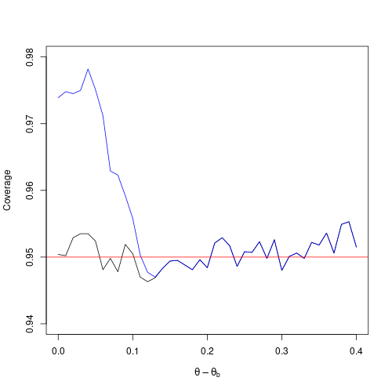

## Animation

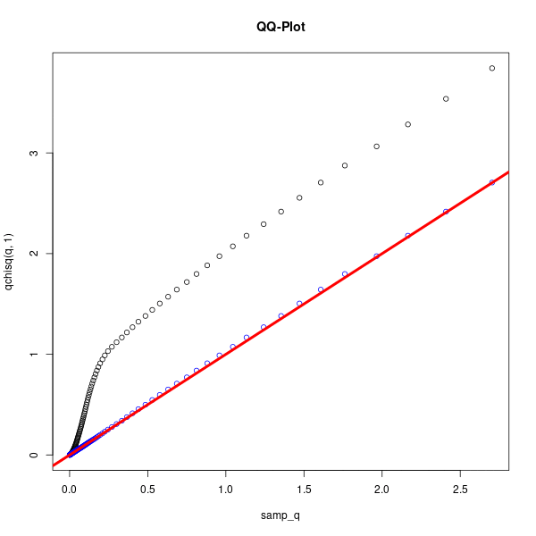

## Nuisance Parameters

- Consider the case where \(\theta = (\psi, \lambda)\), \(\psi\) is parameter of interest, \(\lambda\) nuisance.
- It is not possible to construct random variables \(T^*_n(\psi)\) with the same limiting distribution as \(T_n(\psi)\) under *all* sequences \((\theta_n)\), since the sequence \((\theta_n) = (\psi_n, \lambda_n)\) depends on the sequence \((\lambda_n)\).
- In particular, all three of the following have limiting distributions under \(\theta_n\) which depend on the sequence \((\lambda_n)\):

\[ T^S_n(\psi) = \frac{1}{\sqrt{n}}s_{n, \psi}(\psi_, \hat\lambda_n(\psi)) \\ T^W_n(\psi) = \sqrt{n}(\hat\psi_n - \psi) \\ T^L_n(\psi) = 2\left( \ell_n(\hat\psi_n, \hat\lambda_n) - \ell_n(\psi, \hat\lambda_n(\psi)) \right) \]

## Score Statistic w/ Nuisance Parameters

- Define

\[ \hat\lambda_n(\psi) = \underset{\lambda}{\text{argmax }} \ell_n(\psi_, \lambda) \]

and define a score statistic as follows:

\[ T_n(\psi) = \frac{1}{\sqrt{n}}s_{n, \psi}(\psi_, \hat\lambda_n(\psi)) \]

We want to consider the distribution of \(T_n(\psi_n)\) under a sequence of parameter values \((\theta_n)\)

## Score Statistic

By a 1-term Taylor expansion,

\[ \frac{1}{\sqrt{n}}s_{n, \psi}(\psi_n, \hat\lambda_n) = \frac{1}{\sqrt{n}} s_{n, \psi} (\psi_n, \lambda_n) - I_{\psi\lambda} \sqrt{n} (\hat\lambda_n - \lambda_n) + o_{P_{\theta_n}}(1) \]

where \(\hat\lambda_n = \hat\lambda_n(\psi_n)\). Under LAN assumptions for the sequence of likelihoods \(\ell_n^*(\lambda) = \ell_n(\psi_n, \lambda)\), we have that the quantity \(\sqrt{n}(\hat\lambda_n - \lambda_n)\) converges to the projection of a standard normal onto some set \(H\) which depends on the rate of convergence of \((\lambda_n)\) to its limit \(\lambda_0\).

## Score Statistic

Interestingly, when \(\theta\) is 2-dimensional, \(\Theta = \Psi \times \Lambda\) with \(\Lambda = [\lambda_0, \infty)\), and \(\sqrt{n} (\lambda_n - \lambda_0) \rightarrow b\),

\[ \begin{aligned} ^\lim_{n \rightarrow \infty} P(T_n(\psi_n) \leq t) = \\ P(W \leq (I_{\psi\psi} - I_{\lambda\psi}I_{\lambda\lambda}^{-1}&I_{\psi\lambda})^{-1/2}t) P(W \geq -I_{\lambda\lambda}^{1/2}b) + \\ &P(W^* \leq t) P(W < -I_{\lambda\lambda}^{1/2}b) \end{aligned} \]

where \(W \sim N(0, 1)\), and \(W^* \sim ESN \left( I_{\psi\lambda}b, I_{\psi\psi}, -\rho/\sqrt{1-\rho^2}, I_{\lambda\lambda}^{1/2}b \right)\), and \(\rho = I_{\psi\lambda}/\sqrt{I_{\psi\psi}I_{\lambda\lambda}}\).

## Score Statistic

\(ESN(\xi, \omega^2, \alpha, \tau)\) denotes the four-parameter extended skew normal distribution, with probability density function given by

\[ f(x) = \frac{1}{\omega} g\left( \frac{x - \xi}{\omega} \right) \qquad x \in \mathbb{R} \]

where

\[ g(t) = \phi(t) \frac{\Phi(\tau \sqrt{1+\alpha^2} + \alpha t)}{\Phi(\tau)} \]

## Quasi-Unconstrained Estimator

- Ketz (2018) proposes the following. Define

\[ \tilde\lambda_n = \hat\lambda_n - \left( \frac{\partial^2\ell_n(\hat\lambda_n)}{\partial\lambda\partial\lambda^T}^{-1} s_{n, \lambda}(\hat\lambda_n) \right) \]

- One may show under LAN conditions that

\[ \sqrt{n} (\tilde\lambda_n - \lambda_n) = \frac{s_{n,\lambda}(\lambda_n)/\sqrt{n}}{I_{\lambda\lambda}(\theta_0)} + o_{P_{\theta_n}}(1) \]

## Quasi-Unconstrained Estimator

- We can easily replace the constrained MLE with the quasi-unconstrained version, meaning

\[ \frac{1}{\sqrt{n}}s_{n, \psi}(\psi_n, \tilde\lambda_n) = \frac{1}{\sqrt{n}} s_{n, \psi} (\psi_n, \lambda_n) - I_{\psi\lambda} \sqrt{n} (\tilde\lambda_n - \lambda_n) + o_{P_{\theta_n}}(1) \]

- Note that

\[ \text{cov}\left(\frac{1}{\sqrt{n}} s_{n, \psi} (\psi_n, \lambda_n), \sqrt{n}(\tilde\lambda_n - \lambda_n) \right) = \\ \text{cov}\left(\frac{1}{\sqrt{n}} s_{n, \psi} (\psi_n, \lambda_n), \frac{s_{n,\lambda}(\lambda_n)/\sqrt{n}}{I_{\lambda\lambda}(\theta_0)} + o_{P_{\theta_n}}(1) \right) \]

## Quasi-Unconstrained Estimator

Hence, this score statistic has the usual asymptotic distribution when \(\lambda_n\) is converging to an interior point:

\[ \frac{1}{\sqrt{n}}s_{n, \psi}(\psi_n, \tilde\lambda_n) \overset{\theta_n}\leadsto N(0, I_{\psi\psi} - I_{\lambda\psi}I_{\lambda\lambda}^{-1}I_{\psi\lambda})) \]

and we can construct confidence intervals using normal (or \(\chi^2\)) quantiles.

- This is probably (slightly) better than using just the quasi-unconstrained estimator for the entire parameter vector, \(\tilde\theta_n\) and performing a Wald test, like Ketz (2018) does, but is asymptotically equivalent.

## Conditional Likelihood Ratio Statistic

- In general, confidence intervals constructed using LR are better than score which are better than Wald. Hence, it is of interest to consider inverting an LRT. Ketz does so.

## Future Work (Theory)

- Consider formulating the result for sequences under convergence in law of functions on a Polish space.
- \(W \subset \mathbb{R}^p\) be open, \(C^2(W)\) denote the space of all continuously twice differentiable real-valued functions on \(W\).
- We have

\[ W_n = \sqrt{n}(\Theta - \theta_n) \rightarrow H = W \]

## Future Work (Computation)

- Creating a confidence interval by performing a test on a grid of values, using a warm start.

\[ [\psi^{(1)}, \cdots \psi^{(K)}] \]

use

\[ \hat\lambda_n(\psi^{(k)}) \]

as starting point to find

\[ \hat\lambda_n(\psi^{(k+1)}) \]

- Computational gains made by using the warm start. Computational gains made by using the quasi-unconstrained estimator.

## References

Ekvall, K. O., & Bottai, M. (2025, July 25). Uniform inference in linear mixed models. arXiv.org. https://arxiv.org/abs/2507.19633

Van Der Vaart, A. W. (2000). Asymptotic statistics. Cambridge University Press.

Geyer, C. J. (2012, June 21). Asymptotics of Maximum Likelihood without the LLN or CLT or Sample Size Going to Infinity. arXiv.org. https://arxiv.org/abs/1206.4762

Andrews, D. W. K., & Cheng, X. (2012). Estimation and inference with Weak, Semi-Strong, and strong identification. Econometrica, 80(5), 2153–2211. https://doi.org/10.3982/ecta9456

Cavaliere, G., McCloskey, A., Pedersen, R. S., & Rahbek, A. (2025, July 25). Uniform critical values for likelihood ratio tests in boundary problems. arXiv.org. https://arxiv.org/abs/2507.19603

## References

Cox, G. (2022, September 19). A Generalized Argmax Theorem with Applications. arXiv.org. https://arxiv.org/abs/2209.08793

Fan, Y., & Shi, X. (2021). Uniform Inference in a Generalized Interval Arithmetic Center and Range Linear Model. Econometric Theory, 39(1), 27–69. https://doi.org/10.1017/s0266466621000360

Ketz, P. (2018). Subvector inference when the true parameter vector may be near or at the boundary, Journal of Econometrics, Volume 207, Issue 2, Pages 285-306, ISSN 0304-4076, https://doi.org/10.1016/j.jeconom.2018.08.003.